# Welcome to my Page !

Guillaume FAYNOT

2022-06-02

# Introduction

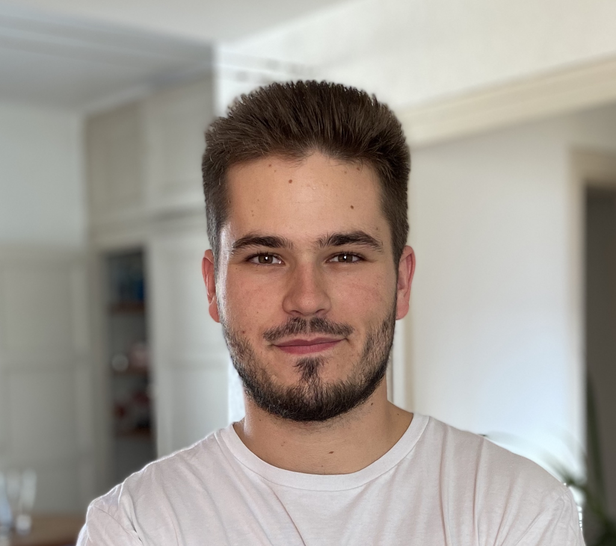

Bonjour à vous !

Je m’appelle Guillaume Faynot, j’ai 24 ans.  
Prochainement diplômé du master Business & Data Analyst, je suis à la recherche d’un emploi en septembre 2022 dans le monde de la data. Dans l’optique de devenir “Data Scientist”, je suis passionné par le domaine de la science des données / data science ! Mes formations et expériences professionnelles m’ont spécialisé dans l’analyse de données avec notamment en réalisant les tâches suivantes :

- Recueil et analyse des données pertinentes pour l’entreprise ;
- Identification des outils d’analyse ;
- Construction d’algorithmes ;
- Élaboration de modèles de prédictions (Machine Learning) ;
- Création de tableaux de bord adaptés et pertinents ;
- Automatisation de processus ;
- Communication des résultats ;

Organisé et déterminé, mon objectif est d’apporter la meilleure aide à la décision possible !

### Vous pouvez retrouver mon curriculum vitae ici :

[figure not shown]

# Expériences professionnelles

## Data Analyst Junior

Type de contrat : Alternance  
Durée : septembre 2021 - septembre 2022  
Entreprise : Digigram

Digigram est une start-up dans l’audio qui vend ses solutions principalement au monde du broadcast et de l’industrie. En effet, elle est présente sur les marchés de la carte son professionnelle ainsi que les codecs. Aujourd’hui, elle dématerialise ses solutions pour de l’audio over IP.

Mon alternance chez Digigram se répartit en 2 projets :

- Projet 1 : Analyse d’un produit de Digigram dématerialisé sur son utilisation par les clients
- Projet 2 : réalisation d’une étude complète des données financières

**Projet 1**

N’ayant aucune information sur l’utilisation du produit par les clients, l’objectif de ce premier projet était de mettre en place des indicateurs/tableaux de bord qui pouvaient refléter la manière dont était utilisé le produit. Mes premières étapes étaient de récupérer les données qui étaient stockées dans des bases de données externes.  
Dans un second temps, il m’a fallu mettre en forme ces données pour qu’elles puissent être analysées. Une fois ces données “propres”, j’ai construit des tableaux de bord avec le package *flexdashboard* sous R.  
Les tableaux de bord sont ensuites placés sur un serveur distant accessible via internet pour que les salariés internes de l’entreprise puissent y accéder.  
Pour terminer, tout ce processus a dû être automatisé pour que les tableaux de bord soient rafraichit tous les jours à 9h du matin.

**Projet 2**

TPE : Analyse des données financières de Digigram

Pour une première analyse, j’ai appliqué des méthodes économétriques pour déterminer les caractéristiques des produits (produits, clients,…) Digigram qui peuvent influencer le chiffre d’affaires de l’entreprise (approche explicative).

Dans un second temps, mon objectif est de analyse, comprendre et prédire au maximum les données financières (approche prédictive). Pour cela, j’utilise des techniques de machine learning pour répondre à ces besoins (Réseau de neurones, algorithme de séries temporelles ARIMA …).  
L’objectif final est de créer une application pour mettre à profit tous ces algorithmes pour que des utilisateurs qui ne connaissent rien au domaine puissent utiliser les algorithmes sans aucun code. Pour cela, j’ai décidé d’utiliser *Shiny* et d’héberger l’application sur un serveur interne.

## Data Management

Type de contrat : Stage  
Durée : Avril 2021 - Août 2021  
Entreprise : Laboratoire HP2

Ce stage, au sein du laboratoire HP2, s’est appliqué sur une base de données européenne ESADA.

Les objectifs de celui-ci sont:

- Amélioration de la qualité de la base de données ESADA
- Amélioration des outils de reporting pour ESADA.

Ce stage m’a apporté beaucoup de compétences notamment:

- Sens de l’organisation+ encadrement étudiant
- Autonomie + esprit d’initiative
- Communication internationale (Stage en anglais)
- Programmation (R & RMarkdown) + Modélisation (Classification de texte avec l’algorithme Support Vector Machine)

## Technicien informatique

Type de contrat : Stage  
Durée : Juin 2020 - Août 2020  
Entreprise : CEA

Ce stage de 2 mois a eu pour objectifs de :

- Nettoyer, traiter et analyser des base de données sous RStudio concernant l’activité de la salle blanche.
- Construction d’un modèle de régression pour comprendre et étudier l’activité de la salle blanche
- Présentation des analyses + résultats sous PowerPoint.
- Création d’une application Shiny (data visualisation).

## Chargé d’études statistiques

Type de contrat : Stage  
Durée : Avril 2019 - Juillet 2019  
Entreprise : G2A Consulting

Mon stage de fin d’étude s’est déroulé à G2A Consulting. G2A Consulting est une entreprise d’environ 20 salariés qui accompagnent les stations de ski et les stations balnéaires à analyser leur activité. Mon stage s’est porté sur l’analyse du rendement tarifaire des remontées mécaniques. En d’autres termes, les missions étaient de mettre à jour les fichiers Excel et présentation powerpoint en se basant sur les nouvelles données de l’année en cours. De plus, j’ai eu l’occasion de travailler à la fin de mon stage sur la création d’une simulation sous Excel. L’objectif était de trouver une solution pour que, basé sur des chiffres entrés, des résultats sortent basés sur des fonctions préalablement données.

- Saisie de données sous Excel + Proposition d’un algorithme VBA
- Présentation des résultats sous PowerPoint
- Proposition d’optimisation des tarifs des forfaits de ski pour l’année N+1
- Réalisation d’un tableau de bord sous Excel